# Training a model to predict the sentiment of the reviews

Aboli Khairnar

Sept, 2020

```r
setwd("/My_Personal_PC/FALL_2020_COURSE_MATERIAL/NLP/Lecture 7/")
```

```r
data <- read.csv("../Lecture 7/movie_reviews_train.csv")

data$ï..text[1]
```

```
## [1] "I grew up (b. 1965) watching and loving the Thunderbirds. All my mates at school watched. We played \"Thunderbirds\" before school, during lunch and after school. We all wanted to be Virgil or Scott. No one wanted to be Alan. Counting down from 5 became an art form. I took my children to see…
```

```r
table(data$label)
```

```
##
##     0     1
## 20019 19981
```

## 1.

### AFINN lexicon:

```r
afinn <- get_sentiments("afinn")
head(afinn)
```

```
## # A tibble: 6 x 2
##   word       value
##   <chr>      <dbl>
## 1 abandon       -2
## 2 abandoned     -2
## 3 abandons      -2
## 4 abducted      -2
## 5 abduction     -2
## 6 abductions    -2
```

```r
# remove words from the stopwords dictionary that appear in AFINN lexicon
afinn_stopwords <- stopwords()[which(stopwords() %in% afinn$word)]
text <- pre_process_corpus_adam(data, "ï..text", replace_emojis = T,
                        non_stopwords = afinn_stopwords)
```

```r
it <- itoken(text, tokenizer = word_tokenizer)
vocab <- create_vocabulary(it)

vectorizer <- vocab_vectorizer(vocab)
dtm <- create_dtm(it, vectorizer)
dim(dtm)
```

```
## [1]  40000 126640
```

#### Note: Precision must be given more weight than recall in this case (i.e. Beta should be lower than 1) in order to avoid mislabeling a negative review as ‘positive’.

```r
dtm <- dtm[, which(colnames(dtm) %in% afinn$word)]
dim(dtm)
```

```
## [1] 40000  2332
```

```r
afinn_reduced <- afinn[afinn$word %in% colnames(dtm),]
dtm <- dtm[, order(colnames(dtm))]
sentiment_values <- dtm %*% as.matrix(afinn_reduced$value)
```

```r
df <- data.frame(assigned_sentiment = data$label,
                 afinn = sentiment_values[,1])

by(df$afinn, df$assigned_sentiment, summary)
```

```
## df$assigned_sentiment: 0
##     Min.  1st Qu.   Median     Mean  3rd Qu.     Max.
## -111.000   -8.000   -1.000   -1.396    6.000  117.000
## ------------------------------------------------------------
## df$assigned_sentiment: 1
##    Min. 1st Qu.  Median    Mean 3rd Qu.    Max.
## -106.00    4.00   11.00   12.59   20.00  173.00
```

```r
df$afinn_pred <- ifelse(df$afinn > 0 , 1, 0)
table(df$assigned_sentiment, df$afinn_pred)
```

```
##
##         0     1
##   0 11126  8893
##   1  3162 16819
```

```r
auc_afinn <- glmnet:::auc(df$assigned_sentiment, df$afinn_pred)
auc_afinn
```

```
## [1] 0.6987608
```

```r
calc_fbeta <- function(df, truth, pred, beta){
  truth <- df[,truth]
  pred <- df[,pred]
  recall <- (nrow(df[(truth == 1) & (pred == 1),]))/
            (nrow(df[truth == 1,]))
  precision <- nrow(df[(truth == 1) & (pred == 1),])/
            (nrow(df[pred == 1,]))

  (1 + beta^2)*(precision * recall)/((beta^2 * precision) + recall)

}
```

```r
calc_fbeta(df,"assigned_sentiment", "afinn_pred", 0.5)
```

```
## [1] 0.684651
```

### NRC lexicon

```r
nrc <- get_sentiments("nrc")

nrc <- nrc[nrc$sentiment %in% c('positive', 'negative'),]
nrc <- nrc[!nrc$word %in% nrc$word[duplicated(nrc$word)],]
nrc$value <- ifelse(nrc$sentiment == 'positive', 1, 0)

# no overlap between nrc and stopwords, so don't need to reprocess text
nrc_stopwords <- stopwords()[which(stopwords() %in% nrc$word)]
#nrc_stopwords

dtm <- create_dtm(it, vectorizer)
dtm <- dtm[, which(colnames(dtm) %in% nrc$word)]

nrc_reduced <- nrc[nrc$word %in% colnames(dtm),]
dtm <- dtm[, order(colnames(dtm))]

sentiment_value <- dtm %*% as.matrix(nrc_reduced$value)

df$nrc <- sentiment_value[,1]

df$nrc_pred <- ifelse(df$nrc > 0, 1, 0)
table(df$assigned_sentiment, df$nrc_pred)
```

```
##
##         0     1
##   0   173 19846
##   1    76 19905
```

```r
auc_nrc <- glmnet:::auc(df$assigned_sentiment, df$nrc_pred)
auc_nrc
```

```
## [1] 0.5024191
```

```r
f2_nrc <- calc_fbeta(df, 'assigned_sentiment', 'nrc_pred', 0.5)
f2_nrc
```

```
## [1] 0.5560522
```

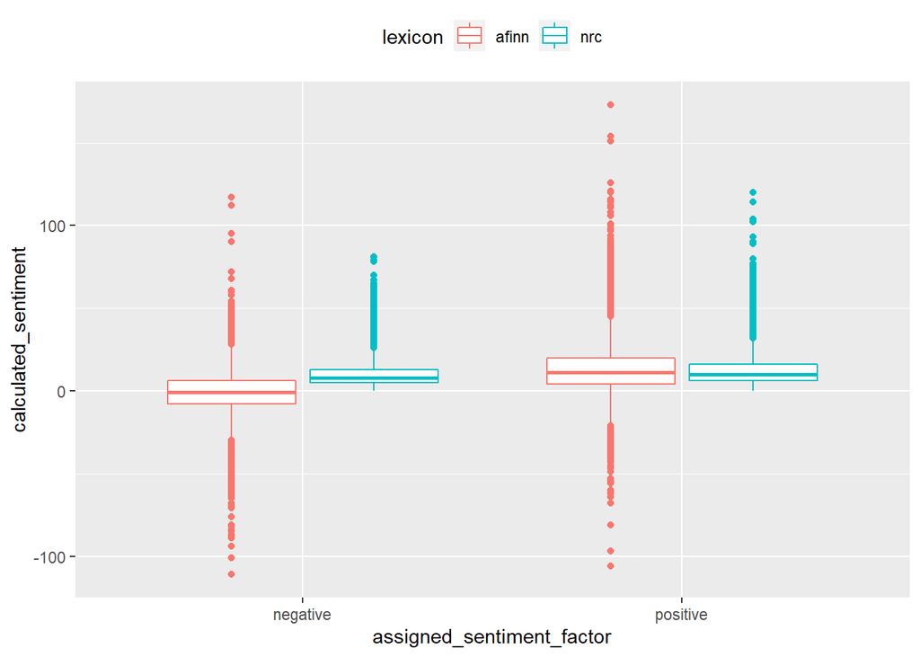

```r
df_long <- melt(df[, c('assigned_sentiment', 'afinn', 'nrc')],
                id = 'assigned_sentiment',
                value.name = 'calculated_sentiment',
                variable.name = 'lexicon')
df_long$assigned_sentiment_factor <- ifelse(df$assigned_sentiment == 1, 'positive', 'negative')
ggplot(df_long, aes(x = assigned_sentiment_factor, y = calculated_sentiment, color = lexicon)) +
  geom_boxplot() +
  scale_size_area(max_size = 50) +
  theme(legend.position = 'top')
```

```r
by(df$nrc, df$assigned_sentiment, summary)
```

```
## df$assigned_sentiment: 0
##    Min. 1st Qu.  Median    Mean 3rd Qu.    Max.
##    0.00    5.00    8.00   10.51   13.00   81.00
## ------------------------------------------------------------
## df$assigned_sentiment: 1
##    Min. 1st Qu.  Median    Mean 3rd Qu.    Max.
##    0.00    6.00   10.00   12.89   16.00  120.00
```

### Managing negation with AFINN lexicon

```r
# list of negation terms
neg_terms <- c('no', 'not', 'none', 'nobody', 'nothing', 'neither', 'nowhere', 'never',
               'hardly', 'scarcely', 'barely')

afinn_neg <- rbind(afinn, data.frame(word = neg_terms[!neg_terms %in% afinn$word],
                                     value = -1))
afinn_neg <- afinn_neg[order(afinn_neg$word),]

dtm <- create_dtm(it, vectorizer)
dtm <- dtm[, which(colnames(dtm) %in% afinn_neg$word)]

afinn_neg_reduced <- afinn_neg[afinn_neg$word %in% colnames(dtm),]
dtm <- dtm[, order(colnames(dtm))]

sentiment_value <- dtm %*% as.matrix(afinn_neg_reduced$value)

df$afinn_neg <- sentiment_value[, 1]
df$afinn_neg_pred <- ifelse(df$afinn_neg > 0, 1, 0)

auc_afinn_neg <- glmnet:::auc(df$assigned_sentiment, df$afinn_neg_pred)
auc_afinn_neg
```

```
## [1] 0.7059212
```

```r
f2_afinn_neg <- calc_fbeta(df, 'assigned_sentiment', 'afinn_neg_pred', 0.5)
f2_afinn_neg
```

```
## [1] 0.6918354
```

### Managing negation with NRC lexicon

```r
nrc_neg <- rbind(nrc, data.frame(word = neg_terms[!neg_terms %in% nrc$word],
                                     sentiment = NA, value = -1))
nrc_neg <- nrc_neg[order(nrc_neg$word),]

dtm <- create_dtm(it, vectorizer)
dtm <- dtm[, which(colnames(dtm) %in% nrc_neg$word)]

nrc_neg_reduced <- nrc_neg[nrc_neg$word %in% colnames(dtm),]
dtm <- dtm[, order(colnames(dtm))]

sentiment_value <- dtm %*% as.matrix(nrc_neg_reduced$value)

df$nrc_neg <- sentiment_value[, 1]
df$nrc_neg_pred <- ifelse(df$nrc_neg > 0, 1, 0)

auc_nrc_neg <- glmnet:::auc(df$assigned_sentiment, df$nrc_neg_pred)
auc_nrc_neg
```

```
## [1] 0.5109295
```

```r
f2_nrc_neg <- calc_fbeta(df, 'assigned_sentiment', 'nrc_neg_pred', 0.5)
f2_nrc_neg
```

```
## [1] 0.5599236
```

### using sentimentr

```r
afinn_sentr <- afinn[!afinn$word %in% lexicon::hash_valence_shifters$x, ]
colnames(afinn_sentr) <- c('x', 'y')
afinn_sentr <- as_key(afinn_sentr)

sent_val_sentr_afinn <- sapply(data$ï..text, function(x) {
  get_sentences(x) %>% sentiment(polarity_dt = afinn_sentr) %>%
  subset(select = sentiment) %>% as.matrix %>% mean
  })

df$afinn_sentr <- sent_val_sentr_afinn
df$afinn_sentr_pred <- ifelse(df$afinn_sentr > 0, 1, 0)

f2_afinn_sentr <- calc_fbeta(df, 'assigned_sentiment',  'afinn_sentr_pred', 0.5)
f2_afinn_sentr
```

[output not shown]

F score (beta = 0.5) is around 0.7 for sentimentr approach with afinn lexicon.

Saving the results in csv format to import it later for plotting model performances.

```r
#write.csv(df, "movie_reviews_sentiment_results.csv")
df <- read.csv('movie_reviews_sentiment_results.csv')
```

#Performance comaprison

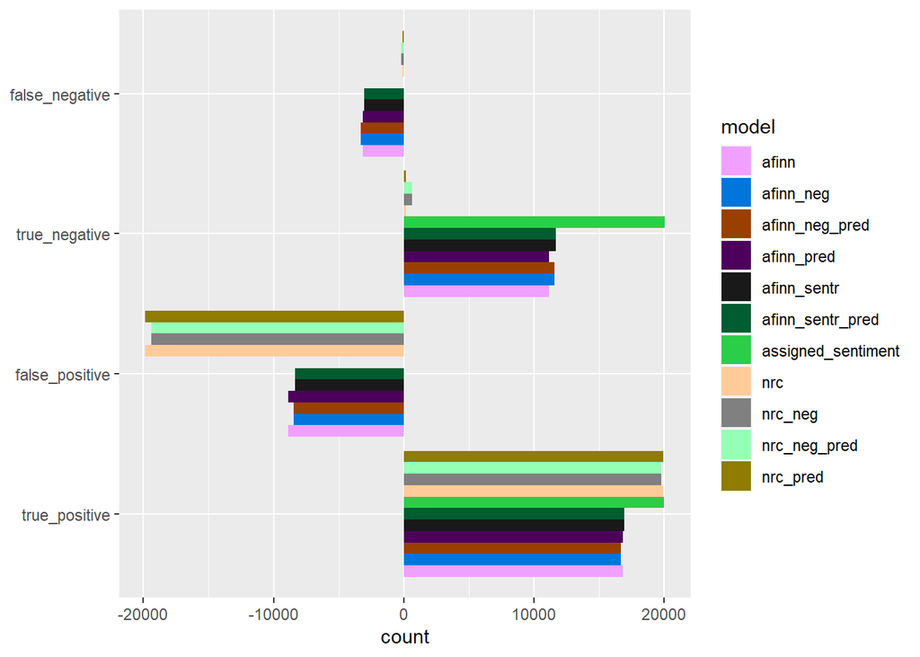

```r
confusion_table <- ldply(apply(df[, -1], 2, function(x) {
  data.frame(true_positive = sum(x > 0 & df$assigned_sentiment == 1),
  false_positive = sum(x > 0 & df$assigned_sentiment == 0) * -1,
  true_negative = sum(x <= 0 & df$assigned_sentiment == 0),
  false_negative = sum(x <= 0 & df$assigned_sentiment == 1) * -1)
}), rbind)

colnames(confusion_table)[1] <- 'model'
confusion_table <- melt(confusion_table, id = 'model', value.name = 'count')

library(pals)
ggplot(confusion_table, aes(x = variable, y = count)) +
  geom_col(aes(fill = model), position = 'dodge') + coord_flip() +
  scale_fill_manual(values = paste0(alphabet(20), "FF"), name = "model") +
  theme(axis.title.y=element_blank())
```

## 2.

Approach worked best to predict positive sentiment: nrc approach (with & without negation) worked the best in predicting positive sentiments.But it fails to predict negative sentiments correctly.(High recall but less precision)

## 3.

F(beta = 0.5) score is highest for afinn_sentr which is around 0.7, However, we will select afinn_neg & afinn (having F (beta = 0.5) score of 0.69 & 0.68 respt.) models to make prediction on test data as they are computationally cheaper than afinn_sentr approach.

```r
data_test <- read.csv("../Lecture 7/movie_reviews_test.csv")

data_test$ï..text[1]
```

```
## [1] "I always wrote this series off as being a complete stink-fest because Jim Belushi was involved in it, and heavily. But then one day a tragic happenstance occurred. After a White Sox game ended I realized that the remote was all the way on the other side of the room somehow. Now I could have …
```

```r
table(data_test$label)
```

```
##
##    0    1
## 2495 2505
```

### AFINN negation approach

```r
afinn <- get_sentiments("afinn")
# remove words from the stopwords dictionary that appear in AFINN lexicon
afinn_stopwords <- stopwords()[which(stopwords() %in% afinn$word)]
text <- pre_process_corpus_adam(data_test, "ï..text", replace_emojis = T,
                        non_stopwords = afinn_stopwords)
```

```r
it <- itoken(text, tokenizer = word_tokenizer)
vocab <- create_vocabulary(it)

vectorizer <- vocab_vectorizer(vocab)
```

```r
# list of negation terms
neg_terms <- c('no', 'not', 'none', 'nobody', 'nothing', 'neither', 'nowhere', 'never',
               'hardly', 'scarcely', 'barely')

afinn_neg <- rbind(afinn, data.frame(word = neg_terms[!neg_terms %in% afinn$word],
                                     value = -1))
afinn_neg <- afinn_neg[order(afinn_neg$word),]

dtm <- create_dtm(it, vectorizer)
dtm <- dtm[, which(colnames(dtm) %in% afinn_neg$word)]

afinn_neg_reduced <- afinn_neg[afinn_neg$word %in% colnames(dtm),]
dtm <- dtm[, order(colnames(dtm))]

sentiment_value <- dtm %*% as.matrix(afinn_neg_reduced$value)

df <- data.frame(assigned_sentiment = data_test$label,
                 afinn_neg = sentiment_value[,1])


df$afinn_neg_pred <- ifelse(df$afinn_neg > 0, 1, 0)

auc_afinn_neg <- glmnet:::auc(df$assigned_sentiment, df$afinn_neg_pred)
auc_afinn_neg
```

```
## [1] 0.7043648
```

```r
f2_afinn_neg <- calc_fbeta(df, 'assigned_sentiment', 'afinn_neg_pred', 0.5)
f2_afinn_neg
```

```
## [1] 0.6925664
```

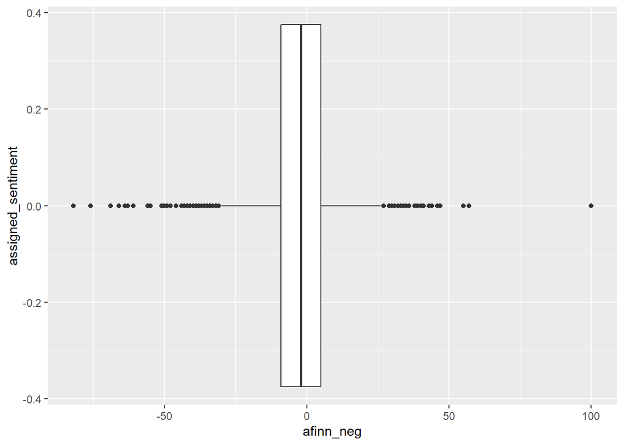

```r
ggplot(df[(df$afinn_neg_pred =! df$assigned_sentiment) & (df$assigned_sentiment = 1),], aes(x = afinn_neg, y = assigned_sentiment)) +
  geom_boxplot()
```

The performance of afinn_neg on test data is as good as it was on the training data!

### AFINN approach (without negation)

```r
it <- itoken(text, tokenizer = word_tokenizer)
vocab <- create_vocabulary(it)

vectorizer <- vocab_vectorizer(vocab)
dtm <- create_dtm(it, vectorizer)
dim(dtm)
```

```
## [1]  5000 44665
```

```r
dtm <- dtm[, which(colnames(dtm) %in% afinn$word)]
dim(dtm)
```

```
## [1] 5000 2002
```

```r
afinn_reduced <- afinn[afinn$word %in% colnames(dtm),]
dtm <- dtm[, order(colnames(dtm))]
sentiment_values <- dtm %*% as.matrix(afinn_reduced$value)
```

```r
df <- data.frame(assigned_sentiment = data_test$label,
                 afinn = sentiment_values[,1])

by(df$afinn, df$assigned_sentiment, summary)
```

```
## df$assigned_sentiment: 0
##    Min. 1st Qu.  Median    Mean 3rd Qu.    Max.
## -76.000  -9.000  -1.000  -1.496   6.000 104.000
## ------------------------------------------------------------
## df$assigned_sentiment: 1
##    Min. 1st Qu.  Median    Mean 3rd Qu.    Max.
##  -67.00    4.00   11.00   12.26   19.00  114.00
```

```r
df$afinn_pred <- ifelse(df$afinn > 0 , 1, 0)
table(df$assigned_sentiment, df$afinn_pred)
```

```
##
##        0    1
##   0 1404 1091
##   1  431 2074
```

```r
auc_afinn <- glmnet:::auc(df$assigned_sentiment, df$afinn_pred)
auc_afinn
```

```
## [1] 0.6953348
```

```r
calc_fbeta(df,"assigned_sentiment", "afinn_pred", 0.5)
```

```
## [1] 0.6838114
```